# HW4_Molotkov

# 1. Add libraries

```r
library(Seurat)
library(Matrix)
library(MAST)
library(ggplot2)
library(dplyr)
```

# 2. Obtain the matrix

Get the data and filter bad barcodes.

```r
data <- Read10X("mat/")
seurat <- CreateSeuratObject(data, min.cells = 20, min.features = 20)

dim(seurat)
```

```
## [1] 16356  6260
```

# 3. Get rid of the dying cells

I will use more strigent thresholds for filtering because they seem more appropriate (for example, mitochondrial RNA < 5% vs 9% from the paper).

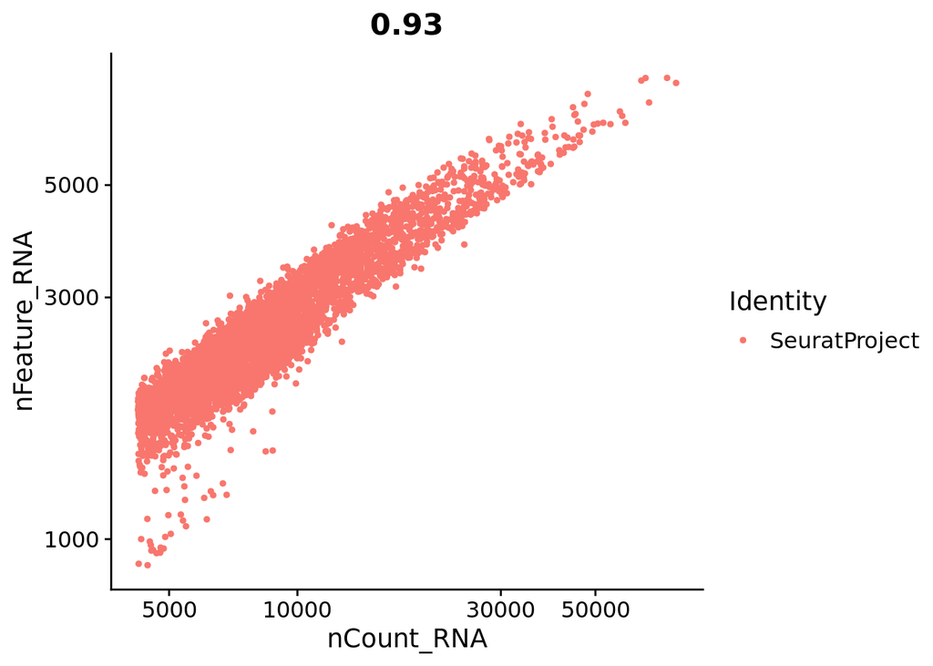

```r
FeatureScatter(seurat, "nCount_RNA", "nFeature_RNA") + scale_x_log10() + scale_y_log10()
```

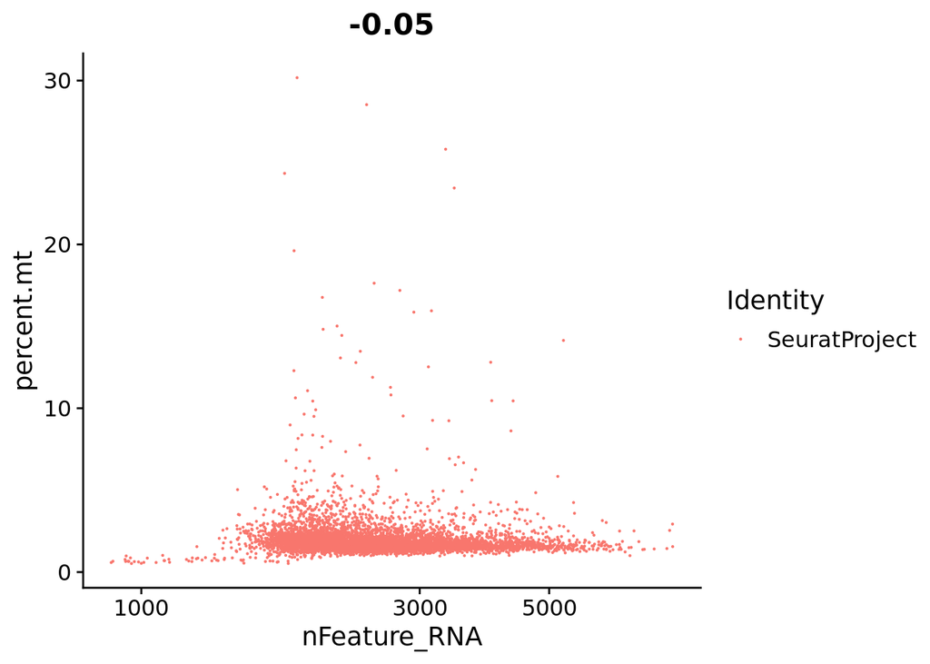

```r
seurat[["percent.mt"]] <- PercentageFeatureSet(seurat, pattern = "^mt-")
FeatureScatter(seurat, "nFeature_RNA", "percent.mt", pt.size = 0.1) + scale_x_log10()
```

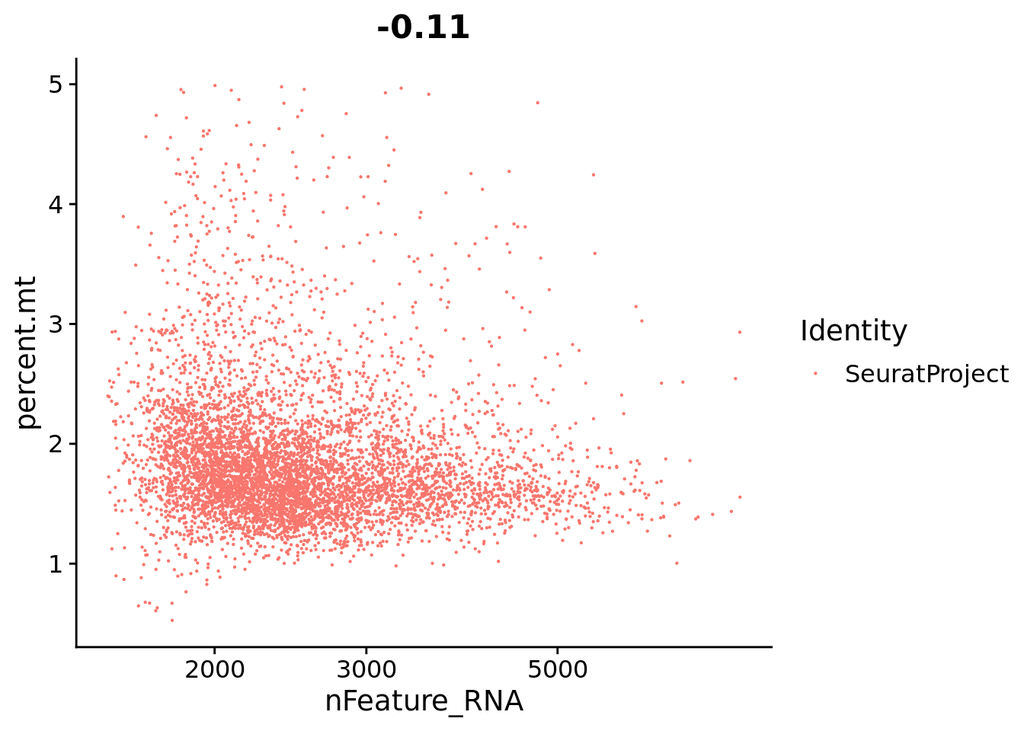

```r
seurat <- subset(seurat, subset = nFeature_RNA > 1500 & percent.mt < 5)

FeatureScatter(seurat, "nFeature_RNA", "percent.mt", pt.size = 0.1) + scale_x_log10()
```

```r
dim(seurat)
```

```
## [1] 16356  6111
```

Overall, after the filtering I have 6111 cells left after the filtering.

# 4. Normalize using SCTransform

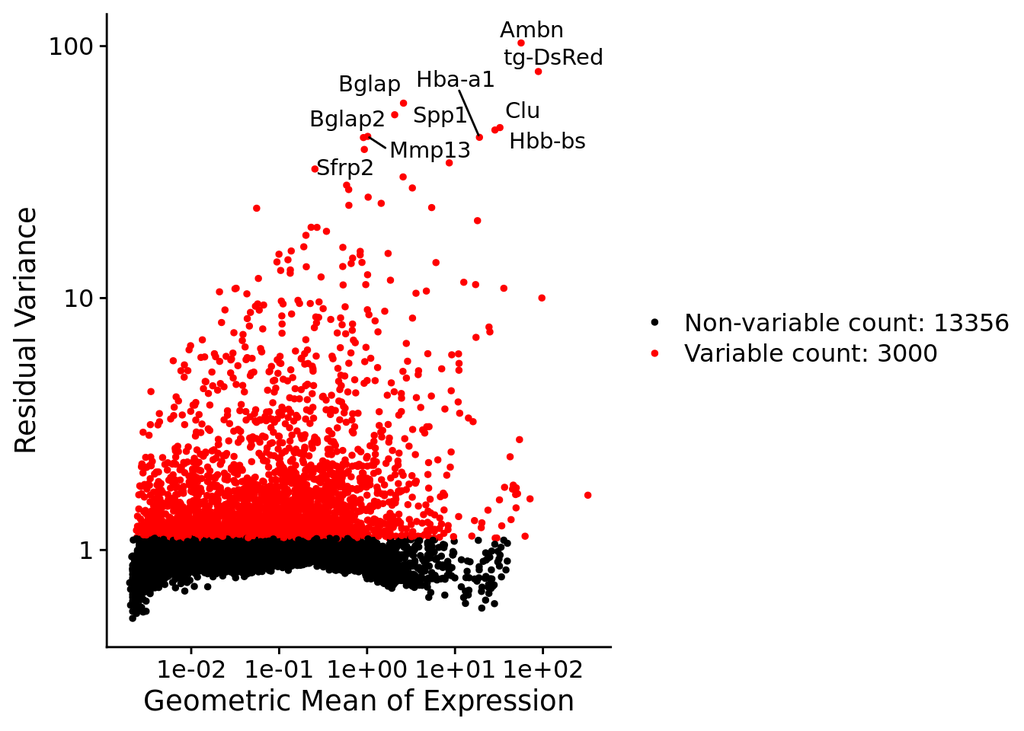

```r
seurat <- SCTransform(seurat, vars.to.regress = "percent.mt", verbose = F)

top10_variable_genes <- head(VariableFeatures(seurat), 10)
VariableFeaturePlot(seurat) %>%
  LabelPoints(points = top10_variable_genes, repel = TRUE) +
  scale_y_log10()
```

# 5. Perform PCA and run UMAP for the visualization

I'm going to use UMAP for the visualization, and not tSNE, like in the paper, because I think UMAP separates the clusters better.

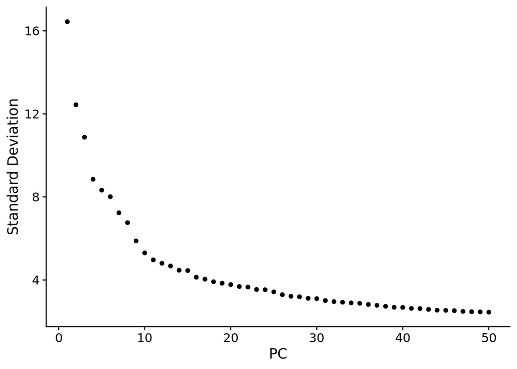

```r
seurat <- RunPCA(seurat)
ElbowPlot(seurat, ndims = 50)
```

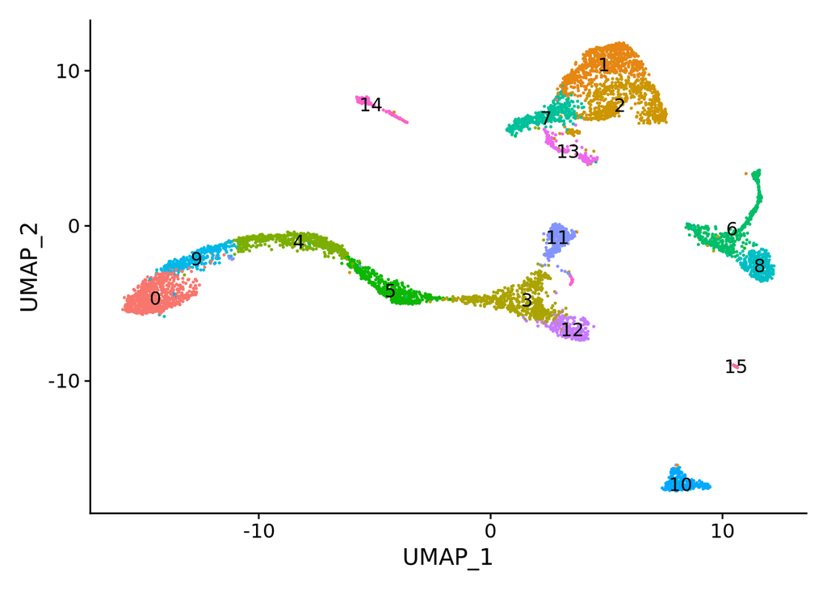

```r
seurat <- RunUMAP(seurat, dims=1:20)
seurat <- RunTSNE(seurat, dims=1:20)
seurat <- FindNeighbors(seurat, dims = 1:20)
seurat <- FindClusters(seurat, resolution=0.6, verbose = F)
DimPlot(seurat, reduction = "umap", label = TRUE) + NoLegend()
```

# 6. Identification of cell populations using markers (reproduction of the results from the paper).

#### 1) Differential gene expression analysis identified Krt14 + epithelial cell, Fn1 + mesenchymal cell, Cdh5 + endothelial cell, and Ccl12 + leukocyte clusters

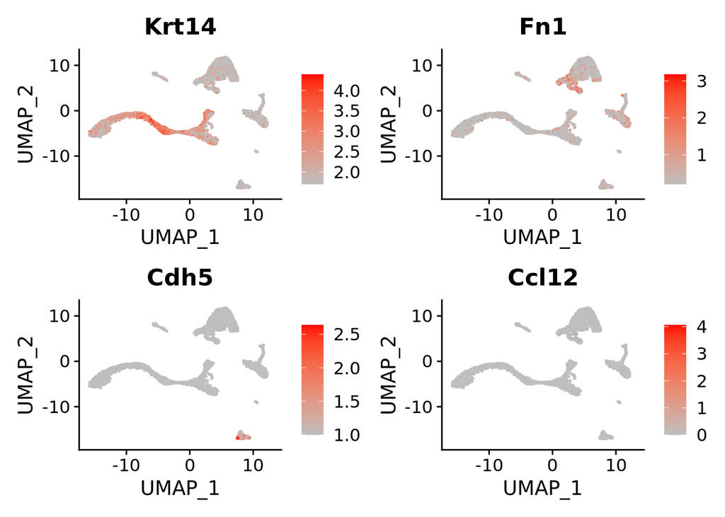

```r
FeaturePlot(seurat, c("Krt14", "Fn1", "Cdh5", "Ccl12"), cols=c("grey", "red"), reduction="umap", ncol=2, min.cutoff = c(1.7, 0.2, 1, 0))
```

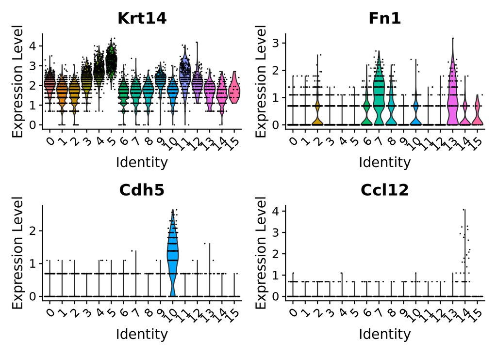

```r
VlnPlot(seurat, c("Krt14", "Fn1", "Cdh5", "Ccl12"), pt.size = 0.01, ncol = 2)
```

#### 2) Dental epithelial cells were classified them into two clusters of ameloblast, IEE/OEE, SI/SR - overall four clusters. The most significant markers from the paper: Dspp (Ameloblast I), Ambn (Ameloblast II), Epcam (IEE/OEE), Tfrc (SI/SR)

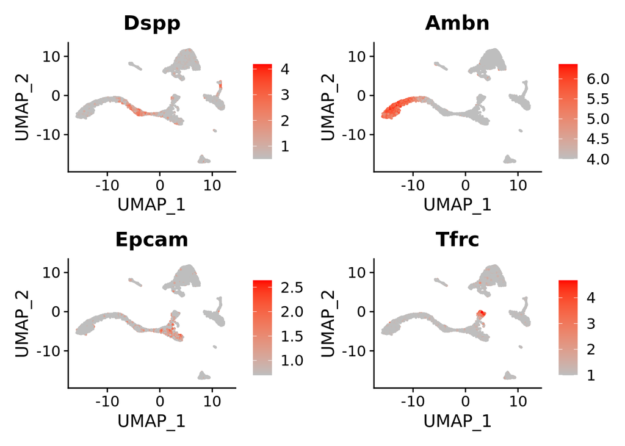

```r
FeaturePlot(seurat, c("Dspp", "Ambn", "Epcam", "Tfrc"), cols=c("grey", "red"), reduction="umap", ncol=2, min.cutoff = c(0.5, 4, 0.7, 1))
```

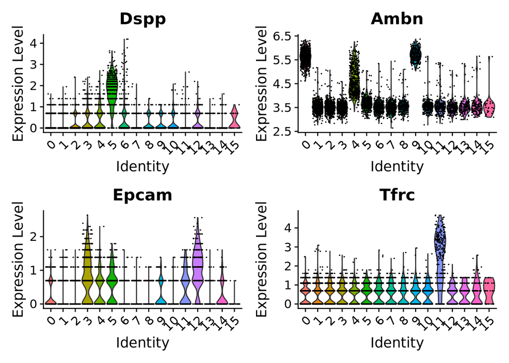

```r
VlnPlot(seurat, c("Dspp", "Ambn", "Epcam", "Tfrc"), pt.size = 0.01, ncol = 2)
```

#### 3) Other significant markers were found: Smpd3 (Odontoblast), Ogn (Mesenchyme), C1qc (Leukocyte), Cdh5 (Endothilial cell)

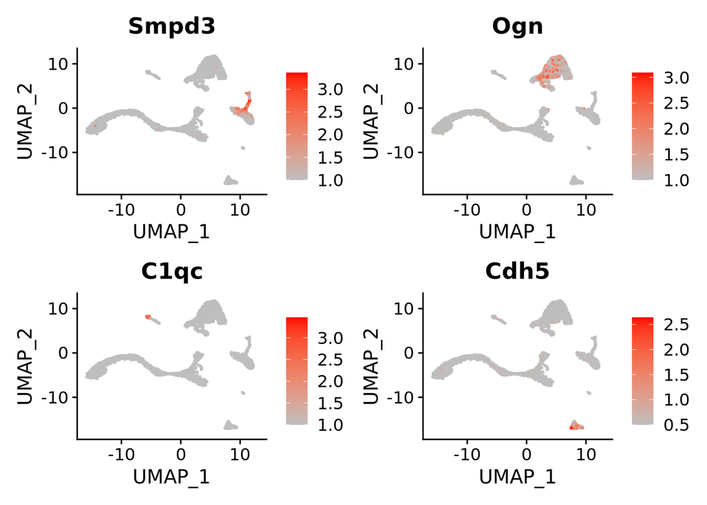

```r
FeaturePlot(seurat, c("Smpd3", "Ogn", "C1qc", "Cdh5"), cols=c("grey", "red"), reduction="umap", ncol=2, min.cutoff = c(1, 1, 1, 0.5))
```

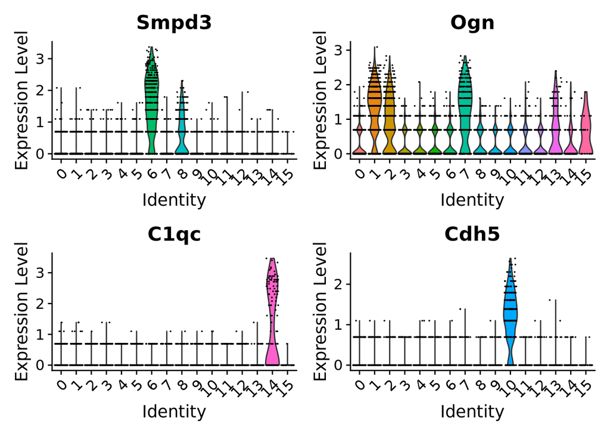

```r
VlnPlot(seurat, c("Smpd3", "Ogn", "C1qc", "Cdh5"), pt.size = 0.01, ncol = 2)
```